# Why Inventory Exists

Manuel D. Rossetti, PhD P.E.

## Agenda

- Inventory looks like a mistake, and is not one: it decouples
- Five kinds of inventory, each created by a different separation
- Pipeline stock, computed from the demand rate and the lead time
- Different causes, different levers, and why a blanket reduction target is dangerous
- One item, three levers pulled one at a time: why lead time wins
- The question is never whether to hold inventory

## Inventory Looks Like a Mistake

Inventory is capital converted into a form that cannot be spent. Forty million dollars of stock is forty million dollars that cannot be used for anything else, sitting in a building that must be heated and insured, exposed to theft, damage, and the possibility that nobody will ever want it.

It is not a mistake. Inventory exists to **decouple**: to break a linkage between two processes that would otherwise have to operate in lockstep. Supply and demand are separated in **space**, in **time**, in **rate**, and in **predictability**, and each separation forces stock into existence somewhere.

Take the inventory away without removing the separation, and the two processes must synchronize, which usually means one of them stops.

## Pipeline Inventory

Supply and demand are separated in **space and time**. Units ordered from a supplier spend the lead time in transit, in production, or awaiting inspection: owned, paid for, and unavailable. That is **pipeline**, or in-transit, inventory.

Let $\lambda$ represent the demand rate and $\overline{L}$ the average lead time. Little’s law, derived next session, gives the average on order:

$$\begin{aligned}
\overline{\mathit{IO}} &= \lambda\,\overline{L}
&&\text{demand rate times average lead time, and nothing else}\\
&= 100 \text{ units a week} \times 6 \text{ weeks} = 600 \text{ units}
&&\text{a supplier six weeks away}
\end{aligned}$$

Notice that its size is **not a decision**: no ordering policy appears in the formula, so no ordering policy can reduce it. The organization owns six hundred units in transit at all times, whatever its reorder point. The only ways to change that number are to sell less or to source closer.

## Cycle Stock and Safety Inventory

**Cycle stock.** Supply and demand are separated in **rate**: consumption is more or less continuous, replenishment arrives in lots. The stock drawn down between deliveries exists only because the arrival was a lot and not a trickle, and it averages half the lot size. It exists because something is incurred once per order regardless of size: an administrative cost, a setup, a truck that costs the same half full or full. The lever is that fixed cost, not the ordering rule: telling the buyer to order less at a time only moves cost from holding into ordering.

**Safety inventory.** Supply and demand are separated in **predictability**. Stock held against uncertainty in demand over the lead time, and in the lead time itself, beyond what average demand over the average lead time requires.

Safety stock is created by **variability, not by level**. With demand a steady hundred a week and a lead time exactly six weeks every time, no safety stock is needed at any service target, however demanding. It is the variance, not the mean, that must be covered.

## Anticipation and Speculative Inventory

**Anticipation inventory.** Supply and demand are separated in rate over a horizon, in a way that is **known in advance**: a plant with fixed capacity facing a seasonal peak builds ahead of it; a distributor stocks up before a promotion, a price increase, or a shutdown. What separates it from safety stock is that the variation is **foreseen**: covered not because it might happen but because it will. The lever is capacity or flexibility, usually decided outside the inventory system.

**Speculative inventory** is held because the item is expected to cost more later, or to become unavailable: a commodity hedge, a buy-ahead, a strategic reserve. It is a financial position denominated in goods, governed by a view about future prices and not by any mechanics in this course.

Speculative stock appears here because it turns up on real balance sheets, where it can dominate the operational categories and distort any attempt to benchmark them.

## Different Causes, Different Levers

| Type | What it decouples | Created by | Reduced by |
| --- | --- | --- | --- |
| Pipeline | Supply and demand in space and time | Lead time | Shorter lead time; closer sourcing |
| Cycle | Continuous consumption from discrete replenishment | A fixed cost per order or setup | Cheaper ordering; faster setups |
| Safety | The system from uncertainty | Variability in demand and lead time | Less variability; shorter lead time; less service |
| Anticipation | Fixed capacity from foreseen variation | A capacity constraint | More, or more flexible, capacity |
| Speculative | The purchase decision from the price | An expected price or supply movement | A change of view about the future |

## A Directive That Is Not Actionable

**A directive to reduce inventory by twenty percent is not actionable**, because it does not say which kind. Each kind responds to a different intervention, most of those take months, and only one of them, reducing safety stock, can be executed by decree.

That asymmetry makes the unspecified mandate dangerous:

1. Faced with a target and a deadline, the only lever available on the deadline is safety stock.
2. So that is the lever pulled, and inventory falls on schedule.
3. The consequence arrives **one lead time later** as stockouts, by which time it is attributed to demand, to suppliers, or to bad luck.

The mandate was met, and the service was spent to meet it.

## Pulling One Lever at a Time

One item: $\lambda = 100$ a year, $k = \$50$, $h = \$5$, $\sigma = 40$ units a year of demand variability, $L = 0.25$ year, $z = 1.645$ for a 95% target. Using results derived later in the course, $Q^{*} = \sqrt{2k\lambda/h}$, cycle stock $Q^{*}/2$, and safety stock $z\sigma\sqrt{L}$:

| Lever | Pipeline $\lambda L$ | Cycle $Q^{*}/2$ | Safety $z\sigma\sqrt{L}$ | Total |
| --- | --- | --- | --- | --- |
| Base case | 25.0 | $\sqrt{2000}/2 = 22.4$ | $1.645(40)(0.5) = 32.9$ | 80.3 |
| Halve the fixed order cost, $k = 25$ | 25.0 | $\sqrt{1000}/2 = 15.8$ | 32.9 | 73.7 |
| Halve the variability, $\sigma = 20$ | 25.0 | 22.4 | $1.645(20)(0.5) = 16.4$ | 63.8 |
| Halve the lead time, $L = 0.125$ | 12.5 | 22.4 | $1.645(40)(0.354) = 23.3$ | 58.1 |

Halving the fixed cost moves only cycle stock; halving the variability moves only safety stock. **Halving the lead time moves two components at once.**

## Why Lead Time Wins

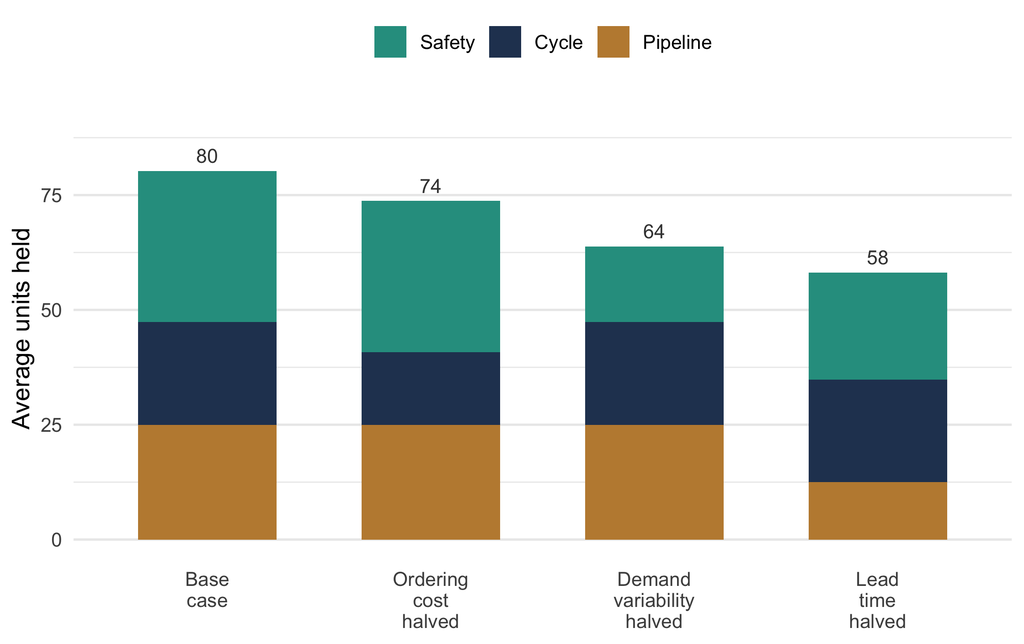

Each bar is the total stock left after one lever is pulled, with the pipeline, cycle and safety components stacked so each can be read separately.

Lead time is the only lever that appears in **two components**: directly in the pipeline, and through the exposure window in the safety stock, where it enters as $\sqrt{L}$.

Thus, lead time reduction is the lever most often underrated in inventory management.

## The Question Is Never Whether

All of this reads as an argument that inventory is a symptom of problems elsewhere: long lead times, expensive setups, unpredictable demand. That much is correct. The conclusion sometimes drawn from it, that the right target is therefore zero, does not follow.

Inventory is not waste. It is a **purchase**, and what it buys is the ability to serve a demand from stock committed before anyone knew the demand would come. Removing it without removing what created it converts a holding cost into a shortage cost, and shortage costs are the ones that appear on no ledger.

The question is never whether to hold inventory. It is **how much, and when to replenish**, given what holding costs and what not holding costs. Every model in this course answers that pair of questions under a particular set of assumptions. The assumptions change from chapter to chapter; the question does not.

## What We Did Today

**Inventory decouples supply from demand,** separated in space, time, rate and predictability.

**Five kinds, five causes:** pipeline from lead time, cycle from a fixed cost per order, safety from variability, anticipation from a capacity constraint, speculative from an expected price movement.

**Pipeline stock is $\lambda\overline{L}$,** and no ordering policy can change it.

**Lead time touches two components,** which is why it wins.

## For Next Time

**Read before next session:** *Classifying Inventory Systems* and *The State of an Inventory System*.

Today’s material was *Why Hold Inventory?*

Next session:

- The nine questions that classify an inventory system, and which costs each answer makes matter
- On hand, on order, backordered, net inventory and inventory position
- Why every policy watches the position and not the shelf
- Time averages, and Little’s law three ways

Bring $\overline{\mathit{IO}} = \lambda\overline{L}$. Next session derives it.

⌂ Index